# TMDB data analysis-Copy1

```python
#import packges we will use for our analysis
import numpy as np
import pandas as pd
import seaborn as sns
import warnings
import matplotlib.pyplot as plt
%matplotlib inline
```

```python
#load data
data = pd.read_csv('tmdb-movies.csv')
```

```python
data.shape
```

```
(10866, 21)
```

```python
print('The no. of rows: ', data.shape[0])
print('The no. of cols: ', data.shape[1])
```

```
The no. of rows:  10866
The no. of cols:  21
```

```python
data.columns
```

```
Index(['id', 'imdb_id', 'popularity', 'budget', 'revenue', 'original_title',
       'cast', 'homepage', 'director', 'tagline', 'keywords', 'overview',
       'runtime', 'genres', 'production_companies', 'release_date',
       'vote_count', 'vote_average', 'release_year', 'budget_adj',
       'revenue_adj'],
      dtype='object')
```

```python
data.info()
```

```
<class 'pandas.core.frame.DataFrame'>
RangeIndex: 10866 entries, 0 to 10865
Data columns (total 21 columns):
 #   Column                Non-Null Count  Dtype
---  ------                --------------  -----
 0   id                    10866 non-null  int64
 1   imdb_id               10856 non-null  object
 2   popularity            10866 non-null  float64
 3   budget                10866 non-null  int64
 4   revenue               10866 non-null  int64
 5   original_title        10866 non-null  object
 6   cast                  10790 non-null  object
 7   homepage              2936 non-null   object
 8   director              10822 non-null  object
 9   tagline               8042 non-null   object
 10  keywords              9373 non-null   object
 11  overview              10862 non-null  object
 12  runtime               10866 non-null  int64
 13  genres                10843 non-null  object
 14  production_companies  9836 non-null   object
 15  release_date          10866 non-null  object
 16  vote_count            10866 non-null  int64
 17  vote_average          10866 non-null  float64
 18  release_year          10866 non-null  int64
 19  budget_adj            10866 non-null  float64
 20  revenue_adj           10866 non-null  float64
dtypes: float64(4), int64(6), object(11)
memory usage: 1.7+ MB
```

```python
#our data has null values and that's the count of the null values for each column
data.isnull().sum()
```

```
id                         0
imdb_id                   10
popularity                 0
budget                     0
revenue                    0
original_title             0
cast                      76
homepage                7930
director                  44
tagline                 2824
keywords                1493
overview                   4
runtime                    0
genres                    23
production_companies    1030
release_date               0
vote_count                 0
vote_average               0
release_year               0
budget_adj                 0
revenue_adj                0
dtype: int64
```

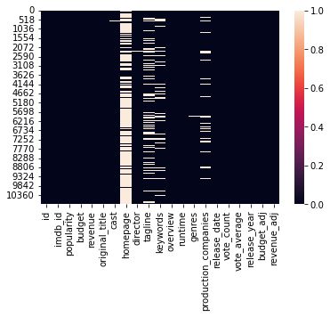

```python
# showing the null values by heatmap
sns.heatmap(data.isnull())
```

```python
#filling our null values with zero
data.fillna(0)
```

|  | id | imdb_id | popularity | budget | revenue | original_title | cast | homepage | director | tagline | ... | overview | runtime | genres | production_companies | release_date | vote_count | vote_average | release_year | budget_adj | revenue_adj |
| --- | --- | --- | --- | --- | --- | --- | --- | --- | --- | --- | --- | --- | --- | --- | --- | --- | --- | --- | --- | --- | --- |
| 0 | 135397 | tt0369610 | 32.985763 | 150000000 | 1513528810 | Jurassic World | Chris Pratt\|Bryce Dallas Howard\|Irrfan Khan\|Vi... | http://www.jurassicworld.com/ | Colin Trevorrow | The park is open. | ... | Twenty-two years after the events of Jurassic ... | 124 | Action\|Adventure\|Science Fiction\|Thriller | Universal Studios\|Amblin Entertainment\|Legenda... | 6/9/15 | 5562 | 6.5 | 2015 | 1.379999e+08 | 1.392446e+09 |
| 1 | 76341 | tt1392190 | 28.419936 | 150000000 | 378436354 | Mad Max: Fury Road | Tom Hardy\|Charlize Theron\|Hugh Keays-Byrne\|Nic... | http://www.madmaxmovie.com/ | George Miller | What a Lovely Day. | ... | An apocalyptic story set in the furthest reach... | 120 | Action\|Adventure\|Science Fiction\|Thriller | Village Roadshow Pictures\|Kennedy Miller Produ... | 5/13/15 | 6185 | 7.1 | 2015 | 1.379999e+08 | 3.481613e+08 |
| 2 | 262500 | tt2908446 | 13.112507 | 110000000 | 295238201 | Insurgent | Shailene Woodley\|Theo James\|Kate Winslet\|Ansel... | http://www.thedivergentseries.movie/#insurgent | Robert Schwentke | One Choice Can Destroy You | ... | Beatrice Prior must confront her inner demons ... | 119 | Adventure\|Science Fiction\|Thriller | Summit Entertainment\|Mandeville Films\|Red Wago... | 3/18/15 | 2480 | 6.3 | 2015 | 1.012000e+08 | 2.716190e+08 |
| 3 | 140607 | tt2488496 | 11.173104 | 200000000 | 2068178225 | Star Wars: The Force Awakens | Harrison Ford\|Mark Hamill\|Carrie Fisher\|Adam D... | http://www.starwars.com/films/star-wars-episod... | J.J. Abrams | Every generation has a story. | ... | Thirty years after defeating the Galactic Empi... | 136 | Action\|Adventure\|Science Fiction\|Fantasy | Lucasfilm\|Truenorth Productions\|Bad Robot | 12/15/15 | 5292 | 7.5 | 2015 | 1.839999e+08 | 1.902723e+09 |
| 4 | 168259 | tt2820852 | 9.335014 | 190000000 | 1506249360 | Furious 7 | Vin Diesel\|Paul Walker\|Jason Statham\|Michelle ... | http://www.furious7.com/ | James Wan | Vengeance Hits Home | ... | Deckard Shaw seeks revenge against Dominic Tor... | 137 | Action\|Crime\|Thriller | Universal Pictures\|Original Film\|Media Rights ... | 4/1/15 | 2947 | 7.3 | 2015 | 1.747999e+08 | 1.385749e+09 |
| ... | ... | ... | ... | ... | ... | ... | ... | ... | ... | ... | ... | ... | ... | ... | ... | ... | ... | ... | ... | ... | ... |
| 10861 | 21 | tt0060371 | 0.080598 | 0 | 0 | The Endless Summer | Michael Hynson\|Robert August\|Lord 'Tally Ho' B... | 0 | Bruce Brown | 0 | ... | The Endless Summer, by Bruce Brown, is one of ... | 95 | Documentary | Bruce Brown Films | 6/15/66 | 11 | 7.4 | 1966 | 0.000000e+00 | 0.000000e+00 |
| 10862 | 20379 | tt0060472 | 0.065543 | 0 | 0 | Grand Prix | James Garner\|Eva Marie Saint\|Yves Montand\|Tosh... | 0 | John Frankenheimer | Cinerama sweeps YOU into a drama of speed and ... | ... | Grand Prix driver Pete Aron is fired by his te... | 176 | Action\|Adventure\|Drama | Cherokee Productions\|Joel Productions\|Douglas ... | 12/21/66 | 20 | 5.7 | 1966 | 0.000000e+00 | 0.000000e+00 |
| 10863 | 39768 | tt0060161 | 0.065141 | 0 | 0 | Beregis Avtomobilya | Innokentiy Smoktunovskiy\|Oleg Efremov\|Georgi Z... | 0 | Eldar Ryazanov | 0 | ... | An insurance agent who moonlights as a carthie... | 94 | Mystery\|Comedy | Mosfilm | 1/1/66 | 11 | 6.5 | 1966 | 0.000000e+00 | 0.000000e+00 |
| 10864 | 21449 | tt0061177 | 0.064317 | 0 | 0 | What's Up, Tiger Lily? | Tatsuya Mihashi\|Akiko Wakabayashi\|Mie Hama\|Joh... | 0 | Woody Allen | WOODY ALLEN STRIKES BACK! | ... | In comic Woody Allen's film debut, he took the... | 80 | Action\|Comedy | Benedict Pictures Corp. | 11/2/66 | 22 | 5.4 | 1966 | 0.000000e+00 | 0.000000e+00 |
| 10865 | 22293 | tt0060666 | 0.035919 | 19000 | 0 | Manos: The Hands of Fate | Harold P. Warren\|Tom Neyman\|John Reynolds\|Dian... | 0 | Harold P. Warren | It's Shocking! It's Beyond Your Imagination! | ... | A family gets lost on the road and stumbles up... | 74 | Horror | Norm-Iris | 11/15/66 | 15 | 1.5 | 1966 | 1.276423e+05 | 0.000000e+00 |

10866 rows × 21 columns

```python
#check if our data has duplicated rows and count them
data.duplicated().sum()
```

```
1
```

```python
#drop the duplicate rown found in the last step
data.drop_duplicates(inplace = True)
```

```python
data.shape
```

```
(10865, 21)
```

```python
print('*After removing duplicate values*')
print('The no. of rows: ', data.shape[0])
print('The no. of cols: ', data.shape[1])
```

```
*After removing duplicate values*
The no. of rows:  10865
The no. of cols:  21
```

```python
#remove the unused columns in the analysis from the dataset
data.drop(['imdb_id', 'homepage', 'tagline', 'overview', 'budget_adj', 'revenue_adj'], axis = 1, inplace = True)
```

```python
data.shape
```

```
(10865, 15)
```

```python
#printing the number of columns after unused columns dropped from the dataset
print('*After removing unused columns*')
print('The no. of rows: ', data.shape[0])
print('The no. of cols: ', data.shape[1])
```

```
*After removing unused columns*
The no. of rows:  10865
The no. of cols:  15
```

```python
#converting the release date from string to datetime format
data['release_date'] = pd.to_datetime(data['release_date'])
data.head()
```

|  | id | popularity | budget | revenue | original_title | cast | director | keywords | runtime | genres | production_companies | release_date | vote_count | vote_average | release_year |
| --- | --- | --- | --- | --- | --- | --- | --- | --- | --- | --- | --- | --- | --- | --- | --- |
| 0 | 135397 | 32.985763 | 150000000 | 1513528810 | Jurassic World | Chris Pratt\|Bryce Dallas Howard\|Irrfan Khan\|Vi... | Colin Trevorrow | monster\|dna\|tyrannosaurus rex\|velociraptor\|island | 124 | Action\|Adventure\|Science Fiction\|Thriller | Universal Studios\|Amblin Entertainment\|Legenda... | 2015-06-09 | 5562 | 6.5 | 2015 |
| 1 | 76341 | 28.419936 | 150000000 | 378436354 | Mad Max: Fury Road | Tom Hardy\|Charlize Theron\|Hugh Keays-Byrne\|Nic... | George Miller | future\|chase\|post-apocalyptic\|dystopia\|australia | 120 | Action\|Adventure\|Science Fiction\|Thriller | Village Roadshow Pictures\|Kennedy Miller Produ... | 2015-05-13 | 6185 | 7.1 | 2015 |
| 2 | 262500 | 13.112507 | 110000000 | 295238201 | Insurgent | Shailene Woodley\|Theo James\|Kate Winslet\|Ansel... | Robert Schwentke | based on novel\|revolution\|dystopia\|sequel\|dyst... | 119 | Adventure\|Science Fiction\|Thriller | Summit Entertainment\|Mandeville Films\|Red Wago... | 2015-03-18 | 2480 | 6.3 | 2015 |
| 3 | 140607 | 11.173104 | 200000000 | 2068178225 | Star Wars: The Force Awakens | Harrison Ford\|Mark Hamill\|Carrie Fisher\|Adam D... | J.J. Abrams | android\|spaceship\|jedi\|space opera\|3d | 136 | Action\|Adventure\|Science Fiction\|Fantasy | Lucasfilm\|Truenorth Productions\|Bad Robot | 2015-12-15 | 5292 | 7.5 | 2015 |
| 4 | 168259 | 9.335014 | 190000000 | 1506249360 | Furious 7 | Vin Diesel\|Paul Walker\|Jason Statham\|Michelle ... | James Wan | car race\|speed\|revenge\|suspense\|car | 137 | Action\|Crime\|Thriller | Universal Pictures\|Original Film\|Media Rights ... | 2015-04-01 | 2947 | 7.3 | 2015 |

```python
#creating a new column of profit, which is the difference between revenue and budget
profit = data['profit'] = data['revenue'] - data['budget']
```

```python
data.columns
```

```
Index(['id', 'popularity', 'budget', 'revenue', 'original_title', 'cast',
       'director', 'keywords', 'runtime', 'genres', 'production_companies',
       'release_date', 'vote_count', 'vote_average', 'release_year', 'profit'],
      dtype='object')
```

```python
data.head()
```

|  | id | popularity | budget | revenue | original_title | cast | director | keywords | runtime | genres | production_companies | release_date | vote_count | vote_average | release_year | profit |
| --- | --- | --- | --- | --- | --- | --- | --- | --- | --- | --- | --- | --- | --- | --- | --- | --- |
| 0 | 135397 | 32.985763 | 150000000 | 1513528810 | Jurassic World | Chris Pratt\|Bryce Dallas Howard\|Irrfan Khan\|Vi... | Colin Trevorrow | monster\|dna\|tyrannosaurus rex\|velociraptor\|island | 124 | Action\|Adventure\|Science Fiction\|Thriller | Universal Studios\|Amblin Entertainment\|Legenda... | 2015-06-09 | 5562 | 6.5 | 2015 | 1363528810 |
| 1 | 76341 | 28.419936 | 150000000 | 378436354 | Mad Max: Fury Road | Tom Hardy\|Charlize Theron\|Hugh Keays-Byrne\|Nic... | George Miller | future\|chase\|post-apocalyptic\|dystopia\|australia | 120 | Action\|Adventure\|Science Fiction\|Thriller | Village Roadshow Pictures\|Kennedy Miller Produ... | 2015-05-13 | 6185 | 7.1 | 2015 | 228436354 |
| 2 | 262500 | 13.112507 | 110000000 | 295238201 | Insurgent | Shailene Woodley\|Theo James\|Kate Winslet\|Ansel... | Robert Schwentke | based on novel\|revolution\|dystopia\|sequel\|dyst... | 119 | Adventure\|Science Fiction\|Thriller | Summit Entertainment\|Mandeville Films\|Red Wago... | 2015-03-18 | 2480 | 6.3 | 2015 | 185238201 |
| 3 | 140607 | 11.173104 | 200000000 | 2068178225 | Star Wars: The Force Awakens | Harrison Ford\|Mark Hamill\|Carrie Fisher\|Adam D... | J.J. Abrams | android\|spaceship\|jedi\|space opera\|3d | 136 | Action\|Adventure\|Science Fiction\|Fantasy | Lucasfilm\|Truenorth Productions\|Bad Robot | 2015-12-15 | 5292 | 7.5 | 2015 | 1868178225 |
| 4 | 168259 | 9.335014 | 190000000 | 1506249360 | Furious 7 | Vin Diesel\|Paul Walker\|Jason Statham\|Michelle ... | James Wan | car race\|speed\|revenge\|suspense\|car | 137 | Action\|Crime\|Thriller | Universal Pictures\|Original Film\|Media Rights ... | 2015-04-01 | 2947 | 7.3 | 2015 | 1316249360 |

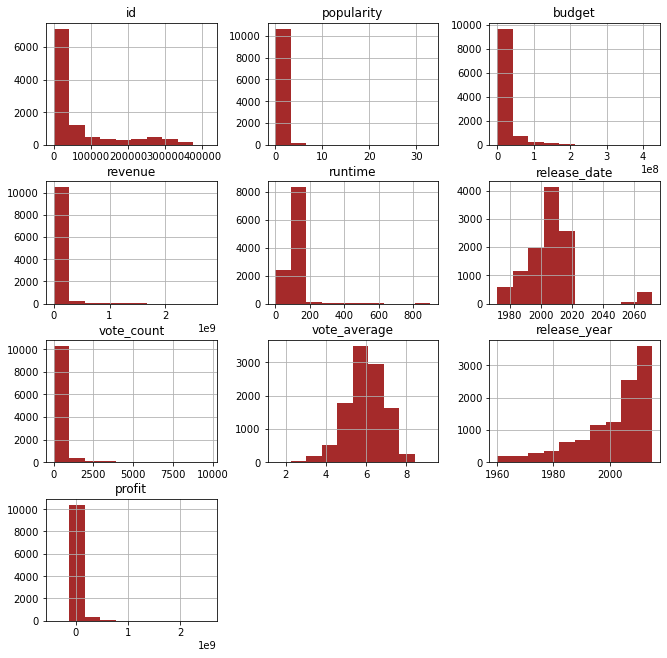

```python
# A histogram to show the distribution of data
data.hist(color = "#A52A2A", figsize=(11,11));
```

```python
data.describe()
```

|  | id | popularity | budget | revenue | runtime | vote_count | vote_average | release_year | profit |
| --- | --- | --- | --- | --- | --- | --- | --- | --- | --- |
| count | 10865.000000 | 10865.000000 | 1.086500e+04 | 1.086500e+04 | 10865.000000 | 10865.000000 | 10865.000000 | 10865.000000 | 1.086500e+04 |
| mean | 66066.374413 | 0.646446 | 1.462429e+07 | 3.982690e+07 | 102.071790 | 217.399632 | 5.975012 | 2001.321859 | 2.520261e+07 |
| std | 92134.091971 | 1.000231 | 3.091428e+07 | 1.170083e+08 | 31.382701 | 575.644627 | 0.935138 | 12.813260 | 9.659103e+07 |
| min | 5.000000 | 0.000065 | 0.000000e+00 | 0.000000e+00 | 0.000000 | 10.000000 | 1.500000 | 1960.000000 | -4.139124e+08 |
| 25% | 10596.000000 | 0.207575 | 0.000000e+00 | 0.000000e+00 | 90.000000 | 17.000000 | 5.400000 | 1995.000000 | 0.000000e+00 |
| 50% | 20662.000000 | 0.383831 | 0.000000e+00 | 0.000000e+00 | 99.000000 | 38.000000 | 6.000000 | 2006.000000 | 0.000000e+00 |
| 75% | 75612.000000 | 0.713857 | 1.500000e+07 | 2.400000e+07 | 111.000000 | 146.000000 | 6.600000 | 2011.000000 | 9.092453e+06 |
| max | 417859.000000 | 32.985763 | 4.250000e+08 | 2.781506e+09 | 900.000000 | 9767.000000 | 9.200000 | 2015.000000 | 2.544506e+09 |

# 1. Which movies are with highest and lowest Budget?

```python
data.columns
```

```
Index(['id', 'popularity', 'budget', 'revenue', 'original_title', 'cast',
       'director', 'keywords', 'runtime', 'genres', 'production_companies',
       'release_date', 'vote_count', 'vote_average', 'release_year', 'profit'],
      dtype='object')
```

[figure not shown]

```python
top_budget = data[(data.budget == data['budget'].max())|(data.budget == data['budget'].min())]
sns.barplot(top_budget['original_title'], top_budget['budget'], palette = 'Paired')
plt.title('Highest & Lowest Budgetary Movies', fontsize = 14)
plt.xlabel('Movie Title')
plt.ylabel('Budget')
warnings.simplefilter(action="ignore", category=FutureWarning)
plt.show()
```

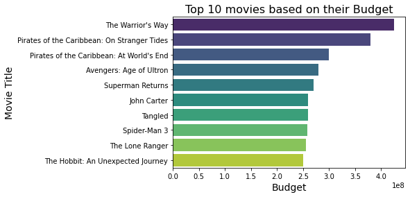

```python
movie_and_budget = data[['original_title','budget']]
sns.barplot( movie_and_budget.sort_values(by='budget', ascending=False).head(10).budget,
              movie_and_budget.sort_values(by='budget', ascending=False).head(10).original_title, palette = 'viridis')

plt.title('Top 10 movies based on their Budget', fontsize = 16)
plt.xlabel('Budget', fontsize = 14)
plt.ylabel('Movie Title', fontsize = 14)

plt.show()
```

"The Warrior's way" is the highest budgetary movie, let's see if it made a high Revenue & Profit then..

# 2. Which movies are with highest and lowest Revenue?

```python
top_revenue = data[(data.revenue == data['revenue'].max())|(data.revenue == data['revenue'].min())]
sns.barplot(top_revenue['original_title'], top_revenue['revenue'], palette = 'Paired')
plt.title('Highest & Lowest Earned Revenue Movies', fontsize = 14)
plt.xlabel('Movie Title')
plt.ylabel('Revenue')
warnings.simplefilter(action="ignore", category=FutureWarning)
plt.show()
```

[output not shown]

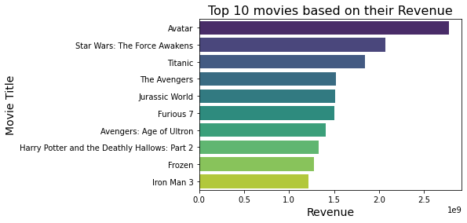

```python
movie_and_revenue = data[['original_title','revenue']]
sns.barplot( movie_and_revenue.sort_values(by='revenue', ascending=False).head(10).revenue,
             movie_and_revenue.sort_values(by='revenue', ascending=False).head(10).original_title, palette = 'viridis')

plt.title('Top 10 movies based on their Revenue', fontsize = 16)
plt.xlabel('Revenue', fontsize = 14)
plt.ylabel('Movie Title', fontsize = 14)

plt.show()
```

It was observed that "Avatar" is the highest earned revenue movie

# 3. Is there a relationship between The Revenue & The Budget?

```
Correlation Between Revenue And Budget :  0.7349279812889231
```

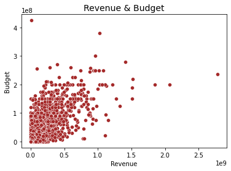

```python
sns.scatterplot(x = data['revenue'], y = data['budget'], color='#A52A2A')

plt.title('Revenue & Budget', fontsize=14)
plt.xlabel('Revenue')
plt.ylabel('Budget')

data_corr = data.corr()
print("Correlation Between Revenue And Budget : ",data_corr.loc['revenue','budget'])
```

There's a positive relationship between Revenues & Budget by 0.73, which means there's a high chance that movies with higher budget make high revenues.

# 4. Which movies are with highest and lowest Profit?

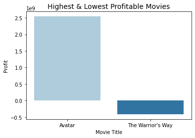

```python
top_profit = data[(data.profit == data['profit'].max())|(data.profit == data['profit'].min())]
sns.barplot(top_profit['original_title'], top_profit['profit'], palette = 'Paired')
plt.title('Highest & Lowest Profitable Movies', fontsize = 14)
plt.xlabel('Movie Title')
plt.ylabel('Profit')
warnings.simplefilter(action="ignore", category=FutureWarning)
plt.show()
```

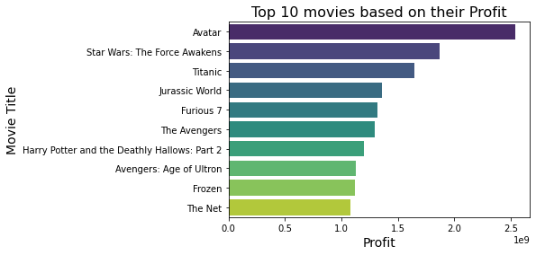

```python
movie_and_profit = data[['original_title','profit']]
sns.barplot( movie_and_profit.sort_values(by='profit', ascending=False).head(10).profit,
              movie_and_profit.sort_values(by='profit', ascending=False).head(10).original_title, palette = 'viridis')

plt.title('Top 10 movies based on their Profit', fontsize = 16)
plt.xlabel('Profit', fontsize = 14)
plt.ylabel('Movie Title', fontsize = 14)

plt.show()
```

"The Warrior's way" is the lowest profitable movie, although it cost a very high budget.

And "Avatar" is the highest profitable movie, although it cost less budget.

# 5. Which movies are with highest and lowest Votes?

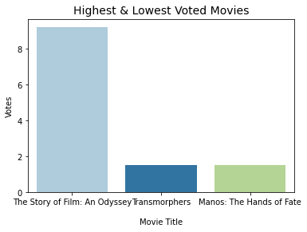

```python
top_votes = data[(data.vote_average == data['vote_average'].max())|(data.vote_average == data['vote_average'].min())]
sns.barplot(top_votes['original_title'], top_votes['vote_average'], palette = 'Paired')
plt.title('Highest & Lowest Voted Movies', fontsize = 14)
plt.xlabel('\nMovie Title')
plt.ylabel('Votes')
warnings.simplefilter(action="ignore", category=FutureWarning)
plt.show()
```

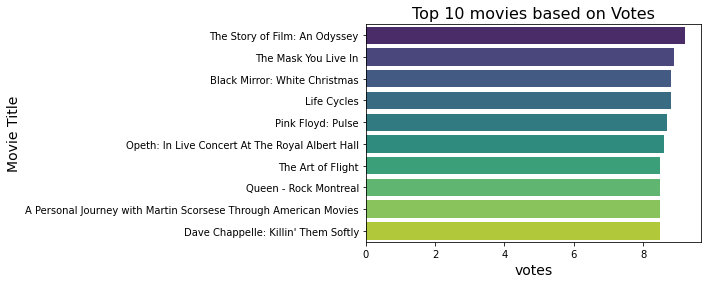

```python
movie_and_votes = data[['original_title','vote_average']]
sns.barplot( movie_and_votes.sort_values(by='vote_average', ascending=False).head(10).vote_average,
              movie_and_votes.sort_values(by='vote_average', ascending=False).head(10).original_title, palette = 'viridis')

plt.title('Top 10 movies based on Votes', fontsize = 16)
plt.xlabel('votes', fontsize = 14)
plt.ylabel('Movie Title', fontsize = 14)

plt.show()
```

"The Story of Film: An Odyssey" is the most voted movie,

And "Transmorphers" & "Manos: The Hands of Fate" are the least voted movies.

# 6. Does Voting Affect The Revenue?

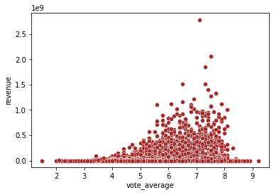

```python
sns.scatterplot(x = 'vote_average', y = 'revenue', data = data, color= "#A52A2A")
```

Voting affection on Revenues is a weak, so whenever average votes high, its not necessarily that revenues are high.

# 7. Classification of Movies Based on Votes

```python
def votes(votes):
    if votes >= 7.0:
        return 'Excellent'
    elif votes >= 6.0:
        return 'Average'
    else:
        return 'Poor'
```

```python
data['vote_class'] = data['vote_average'].apply(votes)
```

```python
data.head()
```

|  | id | popularity | budget | revenue | original_title | cast | director | keywords | runtime | genres | production_companies | release_date | vote_count | vote_average | release_year | profit | vote_class |
| --- | --- | --- | --- | --- | --- | --- | --- | --- | --- | --- | --- | --- | --- | --- | --- | --- | --- |
| 0 | 135397 | 32.985763 | 150000000 | 1513528810 | Jurassic World | Chris Pratt\|Bryce Dallas Howard\|Irrfan Khan\|Vi... | Colin Trevorrow | monster\|dna\|tyrannosaurus rex\|velociraptor\|island | 124 | Action\|Adventure\|Science Fiction\|Thriller | Universal Studios\|Amblin Entertainment\|Legenda... | 2015-06-09 | 5562 | 6.5 | 2015 | 1363528810 | Average |
| 1 | 76341 | 28.419936 | 150000000 | 378436354 | Mad Max: Fury Road | Tom Hardy\|Charlize Theron\|Hugh Keays-Byrne\|Nic... | George Miller | future\|chase\|post-apocalyptic\|dystopia\|australia | 120 | Action\|Adventure\|Science Fiction\|Thriller | Village Roadshow Pictures\|Kennedy Miller Produ... | 2015-05-13 | 6185 | 7.1 | 2015 | 228436354 | Excellent |
| 2 | 262500 | 13.112507 | 110000000 | 295238201 | Insurgent | Shailene Woodley\|Theo James\|Kate Winslet\|Ansel... | Robert Schwentke | based on novel\|revolution\|dystopia\|sequel\|dyst... | 119 | Adventure\|Science Fiction\|Thriller | Summit Entertainment\|Mandeville Films\|Red Wago... | 2015-03-18 | 2480 | 6.3 | 2015 | 185238201 | Average |
| 3 | 140607 | 11.173104 | 200000000 | 2068178225 | Star Wars: The Force Awakens | Harrison Ford\|Mark Hamill\|Carrie Fisher\|Adam D... | J.J. Abrams | android\|spaceship\|jedi\|space opera\|3d | 136 | Action\|Adventure\|Science Fiction\|Fantasy | Lucasfilm\|Truenorth Productions\|Bad Robot | 2015-12-15 | 5292 | 7.5 | 2015 | 1868178225 | Excellent |
| 4 | 168259 | 9.335014 | 190000000 | 1506249360 | Furious 7 | Vin Diesel\|Paul Walker\|Jason Statham\|Michelle ... | James Wan | car race\|speed\|revenge\|suspense\|car | 137 | Action\|Crime\|Thriller | Universal Pictures\|Original Film\|Media Rights ... | 2015-04-01 | 2947 | 7.3 | 2015 | 1316249360 | Excellent |

# 8. Which Genre Has The Highest Release Of Movies?

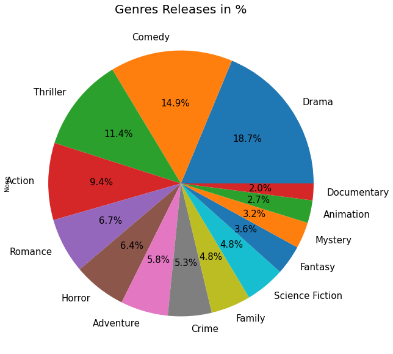

```python
genre = data['genres'].str.get_dummies(sep= '|')
genre_1 = genre[genre.columns].apply(lambda x: sum(x.values))
genre_1.sort_values(0, ascending = False).head(14).plot.pie(figsize = (10,10), fontsize = 15, autopct= "%1.1f%%")
plt.title('Genres Releases in %', fontsize = 20)
plt.show()
```

Observed that Drama genre has the highest release of movies followed by Comedy and Thriller.

# 9. Correlations

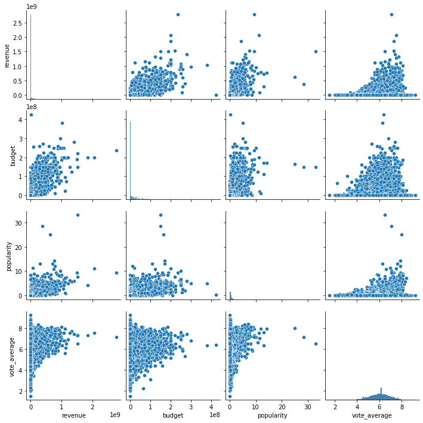

```python
df = data[['revenue', 'budget', 'popularity', 'vote_average']]
sns.pairplot(df)
```